# Reproducible Research - Project 2

Scott Artmann

April 28, 2019

[github repository] - https://github.com/ScottArtmann/Reproducible-Research-Project-2

## Executive Summary - Assignment and Findings

The goal of the assignment is to explore the NOAA Storm Database and explore the effects of severe weather events on both population and economy.The database covers the time period between 1950 and November 2011.

The following analysis investigates which types of severe weather events are most harmful on:

1.Health (injuries and fatalities)

2.Property and crops (economic consequences)

U.S. National Oceanic and Atmospheric Administration’s (NOAA) storm database began tracking storm data events in 1950, categorizing them into 48 discrete types in 1996. Analysis of storm data events from 1996 to 2011 found that Hurricanes/Typhoons cause the most economic impact in relation to crop and property damage, while Tornados take the most population toll in regards to injuries and fatalities.

## Data Processing

### Retrieval and Loading

The compressed data is conditionally downloaded from the source URL if not found locally and then loaded directly via `read.csv`.

```r
filename <- 'StormData.csv.bz2'
if (!file.exists(filename)) {
  download.file('https://d396qusza40orc.cloudfront.net/repdata%2Fdata%2FStormData.csv.bz2', filename)
}
storm_data <- read.csv(filename)
# Ensure we got the data downloaded, decompressed and loaded correctly
# by checking filesize and dataset dimemsions
stopifnot(file.size(filename) == 49177144)
stopifnot(dim(storm_data) == c(902297,37))
```

### Cleaning and Preparation

After the dataset is loaded, it is cleaned as follows:

```r
ExponentToMultiplier <- function(exp) {
  ifelse(
    exp == '+', 1,                         # '+' -> 1
    ifelse(
      exp %in% paste(seq(0,8)), 10^1,      # 0-8 -> 10
      ifelse(
        exp %in% c('H', 'h'), 10^2,        # H,h -> 100
        ifelse(
          exp %in% c('K', 'k'), 10^3,      # K,k -> 1,000
          ifelse(
            exp %in% c('M', 'm'), 10^6,    # M,m -> 1,000,000
            ifelse(
              exp %in% c('B', 'b'), 10^9,  # B,b -> 1,000,000,000
              0                            # everything else -> 0
            )
          )
        )
      )
    )
  )
}
storm_data$PropDamageMult <- ExponentToMultiplier(storm_data$PROPDMGEXP)
storm_data$CropDamageMult <- ExponentToMultiplier(storm_data$CROPDMGEXP)
```

2. Once mulitplier variables have been created, `CropDamage` and `PropDamage` variables are multiplied by the corresponding damage variables `PROPDMG` and `CROPDMG`. In addition, a `TotalDamage` variable is also added, providing the sum of both crop and property damage.

```r
storm_data$PropDamage  <- storm_data$PROPDMG * storm_data$PropDamageMult
storm_data$CropDamage  <- storm_data$CROPDMG * storm_data$CropDamageMult
storm_data$TotalDamage <- storm_data$PropDamage + storm_data$CropDamage
```

3. For assessing the health impact of events, a `PopulationHealthImpact` variable is added as the sum of `FATALITIES` and `INJURIES` variables.

```r
storm_data$PopulationHealthImpact <- storm_data$FATALITIES + storm_data$INJURIES
```

4. To make the dataset easier to work with, irrelevant observations were removed. According to the documentation, discrete event types were not consistently recorded until 1996. Because of this deficit in the data, the years from the dataset earlier than that are removed in order to get a fair and consistent assessment of all events. Also, since we are answering questions around economic and population health impact, all rows with xero impact are removed as well.

```r
storm_data$BeginDate   <- as.Date(storm_data$BGN_DATE, '%m/%d/%Y')
sd <- storm_data[storm_data$BeginDate >= '1996-01-01',]
sd <- sd[sd$TotalDamage > 0 | sd$PopulationHealthImpact  > 0,]
```

5. Looking at the top events with the most `TotalDamage` and `PopulationHealthImpact` led to a data issue it was found that one data point was carried **B**illion instead of **M**illion. The erroneous `PROPDMGEXP` value was then corrected and the `PropDamageMult`, `PropDamage` and `TotalDamage` variables were recalculated.

```r
sd$PROPDMGEXP[sd$REFNUM=='605943'] <- 'M'
sd$PropDamageMult <- ExponentToMultiplier(sd$PROPDMGEXP)
sd$PropDamage  <- sd$PROPDMG * sd$PropDamageMult
sd$TotalDamage <- sd$PropDamage + sd$CropDamage
```

After checking the remaining top 5 by damage and health impact, it was found those are consistent with data available in the NOAA database. See appendix B for more information on the checks of the top individual events. 6. Given the poor consistency of the values found in the `EVTYPE` variable, it was decided to use the list of Event names from Section 2.1.1 of the [Storm Data Documentation](https://d396qusza40orc.cloudfront.net/repdata%2Fpeer2_doc%2Fpd01016005curr.pdf). Using various techniques, a new tidy variable named `EventType` was created containing one of these 48 event types or the value `UNCATEGORIZED` indicating the event was not included. All observations start off as `UNCATEGORIZED` and then updated with different approaches with one of the 48 values.

```r
eventTypes <- c('Astronomical Low Tide', 'Avalanche', 'Blizzard', 'Coastal Flood', 'Cold/Wind Chill',
                'Debris Flow', 'Dense Fog', 'Dense Smoke', 'Drought', 'Dust Devil', 'Dust Storm',
                'Excessive Heat', 'Extreme Cold/Wind Chill', 'Flash Flood', 'Flood', 'Frost/Freeze',
                'Funnel Cloud', 'Freezing Fog', 'Hail', 'Heat', 'Heavy Rain', 'Heavy Snow', 'High Surf',
                'High Wind', 'Hurricane (Typhoon)', 'Ice Storm', 'Lake-Effect Snow', 'Lakeshore Flood',
                'Lightning', 'Marine Hail', 'Marine High Wind', 'Marine Strong Wind',
                'Marine Thunderstorm Wind', 'Rip Current', 'Seiche', 'Sleet', 'Storm Surge/Tide',
                'Strong Wind', 'Thunderstorm Wind', 'Tornado', 'Tropical Depression', 'Tropical Storm',
                'Tsunami', 'Volcanic Ash', 'Waterspout', 'Wildfire', 'Winter Storm', 'Winter Weather')
sd$EventType <- 'UNCATEGORIZED'  # start all EventTypes off as "Uncategorized"
```

```r
sd$EVTYPE <- toupper(trimws(sd$EVTYPE))
```

Setting `EventType` values from `EVTYPE` data utilized a text matching approach based on: * Ignoring all whitespace and capitalization  
* Ignoring all non-alpha characters * Allowing for plural variations (WIND/WIND**S**) * Allowing for verb variations (FLOOD/FLOOD**ING**)

```r
regex <- "[^[:alpha:]]" # match all non-alpha
for(eventType in eventTypes) {
  strippedEventType <- toupper(gsub(regex, '', eventType))
  sd$EventType[gsub(regex, '', sd$EVTYPE) == strippedEventType] <- eventType
  sd$EventType[gsub(regex, '', sd$EVTYPE) == paste(strippedEventType, 'S',   sep='')] <- eventType
  sd$EventType[gsub(regex, '', sd$EVTYPE) == paste(strippedEventType, 'ING', sep='')] <- eventType
}
```

### Normalize the event types

The type of each weather event is stored in the column `EVTYPE` of the dataset.

In order to improve the analysis quality the event types reported needs to be normalized.

```r
coastalFloodAliases <- c('ASTRONOMICAL HIGH TIDE', 'TIDAL FLOODING', 'COASTAL FLOODING/EROSION',
                         'COASTAL  FLOODING/EROSION', 'EROSION/CSTL FLOOD')
sd$EventType[sd$EVTYPE %in% coastalFloodAliases] <- 'Coastal Flood'

winterWeatherAliases <- c('LIGHT FREEZING RAIN', 'ICY ROADS', 'GLAZE', 'FREEZING RAIN',
                          'FREEZING DRIZZLE', 'LIGHT SNOW', 'LIGHT SNOWFALL', 'WINTER WEATHER/MIX',
                          'MIXED PRECIPITATION', 'MIXED PRECIP', 'WINTRY MIX', 'RAIN/SNOW',
                          'WINTER WEATHER MIX')
sd$EventType[sd$EVTYPE %in% winterWeatherAliases] <- 'Winter Weather'
heavySnowAliases <- c('EXCESSIVE SNOW', 'SNOW', 'HEAVY SNOW SHOWER', 'SNOW SQUALL', 'SNOW SQUALLS')
sd$EventType[sd$EVTYPE %in% heavySnowAliases] <- 'Heavy Snow'
highWindAliases <- c('WIND', 'WINDS', 'GUSTY WINDS', 'GUSTY WIND', 'HIGH WIND (G40)',
                     'NON TSTM WIND',  'NON-TSTM WIND', 'WIND DAMAGE', 'NON TSTM WIND',
                     'NON-SEVERE WIND DAMAGE', 'GRADIENT WIND')
sd$EventType[sd$EVTYPE %in% highWindAliases] <- 'High Wind'
freezeAliases <- c('FREEZE', 'DAMAGING FREEZE', 'EARLY FROST', 'FROST', 'AGRICULTURAL FREEZE',
                   'HARD FREEZE', 'UNSEASONABLY COLD', 'UNSEASONABLE COLD')
sd$EventType[sd$EVTYPE %in% freezeAliases] <- 'Frost/Freeze'
extremeColdAliases <- c('EXTREME WINDCHILL', 'EXTREME COLD')
sd$EventType[sd$EVTYPE %in% extremeColdAliases] <- 'Extreme Cold/Wind Chill'
floodAliases <- c('RIVER FLOODING', 'RIVER FLOOD', 'URBAN/SML STREAM FLD', 'URBAN FLOOD')
sd$EventType[sd$EVTYPE %in% floodAliases] <- 'Flood'
flashFloodAliases <- c('FLASH FLOOD/FLOOD', 'FLOOD/FLASH/FLOOD')
sd$EventType[sd$EVTYPE %in% flashFloodAliases] <- 'Flash Flood'
thunderstormAliases <- c('TSTM WIND', 'TSTM WINDS', 'THUNDERSTORM', 'THUNDERSTORMS',
                         'THUNDERSTORM WINDSS', 'THUNDERSTORMS WINDS', 'DRY MICROBURST',
                         'TSTM WIND (G40)', 'THUNDERSTORM WIND/ TREES', 'MICROBURST',
                         'WET MICROBURST', 'THUNDERTORM WINDS', 'THUNDERSTORMS WIND',
                         'SEVERE THUNDERSTORM WINDS', 'TSTM WIND 55', 'THUNDERSTORM WIND 60 MPH',
                         'TSTM WIND (G45)', 'SEVERE THUNDERSTORM', 'THUDERSTORM WINDS',
                         'THUNDEERSTORM WINDS', 'THUNDERESTORM WINDS', 'TSTM WIND 40',
                         'TSTM WIND G45', 'TSTM WIND  (G45)', 'TSTM WIND (41)', 'TSTM WIND 45',
                         'TSTM WIND (G35)', 'TSTM WIND AND LIGHTNING', 'TSTM WIND/HAIL',
                         'THUNDERSTORM WIND (G40)')
sd$EventType[sd$EVTYPE %in% thunderstormAliases] <- 'Thunderstorm Wind'
hailAliases <- c('HAIL DAMAGE', 'SMALL HAIL', 'HAILSTORM')
sd$EventType[sd$EVTYPE %in% hailAliases] <- 'Hail'
hurricaneAliases <- c('HURRICANE', 'TYPHOON', 'HURRICANE OPAL', 'HURRICANE ERIN',
                      'HURRICANE EDOUARD', 'HURRICANE EMILY', 'HURRICANE FELIX',
                      'HURRICANE GORDON', 'HURRICANE OPAL/HIGH WINDS')
sd$EventType[sd$EVTYPE %in% hurricaneAliases] <- 'Hurricane (Typhoon)'
highSurfAliases <- c('HEAVY SURF/HIGH SURF', 'HEAVY SURF', 'HIGH SURF ADVISORY')
sd$EventType[sd$EVTYPE %in% highSurfAliases] <- 'High Surf'
wildfireAliases = c('WILD/FOREST FIRE', 'BRUSH FIRE')
sd$EventType[sd$EVTYPE %in% wildfireAliases] <- 'Wildfire'
heatAliases = c('UNSEASONABLY WARM', 'WARM WEATHER')
sd$EventType[sd$EVTYPE %in% heatAliases] <- 'Heat'
excessiveHeatAliases = c('HEAT WAVE', 'RECORD HEAT')
sd$EventType[sd$EVTYPE %in% excessiveHeatAliases] <- 'Excessive Heat'
heavyRainAliases = c('TORRENTIAL RAINFALL', 'RAIN', 'UNSEASONAL RAIN')
sd$EventType[sd$EVTYPE %in% heavyRainAliases]  <- 'Heavy Rain'
# one-offs
sd$EventType[sd$EVTYPE == 'LANDSPOUT']         <- 'Tornado'
sd$EventType[sd$EVTYPE == 'FOG']               <- 'Dense Fog'
sd$EventType[sd$EVTYPE == 'MARINE TSTM WIND']  <- 'Marine Thunderstorm Wind'
sd$EventType[sd$EVTYPE == 'LANDSLIDE']         <- 'Debris Flow'
sd$EventType[sd$EVTYPE == 'STORM SURGE']       <- 'Storm Surge/Tide'
sd$EventType[sd$EVTYPE == 'COLD']              <- 'Cold/Wind Chill'
```

## Results

### Event Types with Greatest Health Impact

```r
top_health <- head(
  arrange(
    aggregate(
      cbind(FATALITIES, INJURIES, PopulationHealthImpact) ~ EventType, sd, FUN = sum),
    desc(PopulationHealthImpact)
  ),
  n=5
)
kable(
  top_health,
  caption = 'Top 5 Event Types with Greatest Health Impact'
)
```

Top 5 Event Types with Greatest Health Impact

| EventType | FATALITIES | INJURIES | PopulationHealthImpact |
| --- | --- | --- | --- |
| Tornado | 1511 | 20667 | 22178 |
| Excessive Heat | 1799 | 6461 | 8260 |
| Flood | 444 | 6838 | 7282 |
| Thunderstorm Wind | 382 | 5154 | 5536 |
| Lightning | 651 | 4141 | 4792 |

Tornado events top the list here, with over two and half times the health impact of second place, which is Excessive Heat. Excessive Heat is worth noting however, as it has the most fatalities overall.

Next we will look a bit deeper at the data, plotting the yearly total health impact for these top 5.

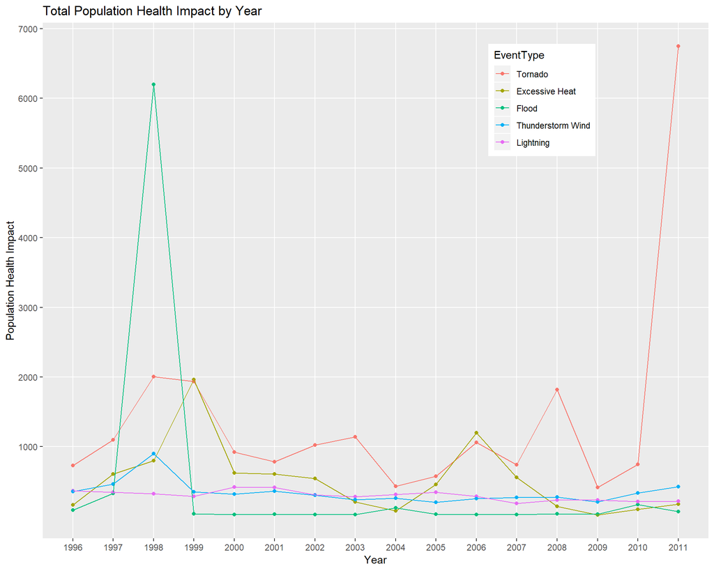

```r
health_by_type_and_year <- aggregate(
  cbind(FATALITIES, INJURIES, PopulationHealthImpact) ~ EventType + year(BeginDate),
  sd,
  FUN=sum
)
names(health_by_type_and_year) <- c('EventType', 'Year', 'Fatalities', 'Injuries', 'PopulationHealthImpact')
health_by_type_and_year <- health_by_type_and_year[health_by_type_and_year$EventType %in% top_health$EventType,]
health_by_type_and_year$EventType <- with(health_by_type_and_year, reorder(EventType, -PopulationHealthImpact))
ggplot(health_by_type_and_year, aes(x=Year, y=PopulationHealthImpact, colour = EventType)) +
  geom_point() + geom_line() +
  scale_x_continuous(breaks = unique(health_by_type_and_year$Year)) +
  scale_y_continuous(
    'Population Health Impact',
    breaks = seq(1000, 7000, by=1000)
  ) +
  ggtitle("Total Population Health Impact by Year") +
  theme(
    legend.position = c(0.75, 0.85),
    panel.grid.minor = element_blank()
  )
```

Looking at the plot, Tornados have a solid yearly trend despite the record breaking year. Flood events however have an overall low yearly trend in comparison to the other top 5 except for 1998. Without this year, flood events would have been in last place instead of third amongst the current top 5. Additional analysis would be needed, but there is good chance that floods would not have made the top 5 at all without the 1998 Texas floods.

### Event Types with Greatest Economic Impact

```r
top_damage <- head(
  arrange(
    aggregate(
      cbind(CropDamage, PropDamage, TotalDamage) ~ EventType, sd, FUN=sum),
    desc(TotalDamage)
  ),
  n=5
)
kable(
  top_damage,
  format.args = list(big.mark = ","),
  caption = 'Top 5 Event Types with Greatest Economic Consequences'
)
```

Top 5 Event Types with Greatest Economic Consequences

| EventType | CropDamage | PropDamage | TotalDamage |
| --- | --- | --- | --- |
| Hurricane (Typhoon) | 5,350,107,800 | 81,718,889,010 | 87,068,996,810 |
| Storm Surge/Tide | 855,000 | 47,834,724,000 | 47,835,579,000 |
| Flood | 5,013,161,500 | 29,244,580,200 | 34,257,741,700 |
| Tornado | 283,425,010 | 24,616,952,710 | 24,900,377,720 |
| Hail | 2,496,822,450 | 14,595,213,420 | 17,092,035,870 |

Hurricanes top the list with $87 billion, which is almost double the next in line which is Storm Surge/Tide events at $47 billion. One interesting note is that Flood events caused almost as much crop damage as hurricanes despite being a distant third place overall.

Let’s look at the yearly trend for these top five.

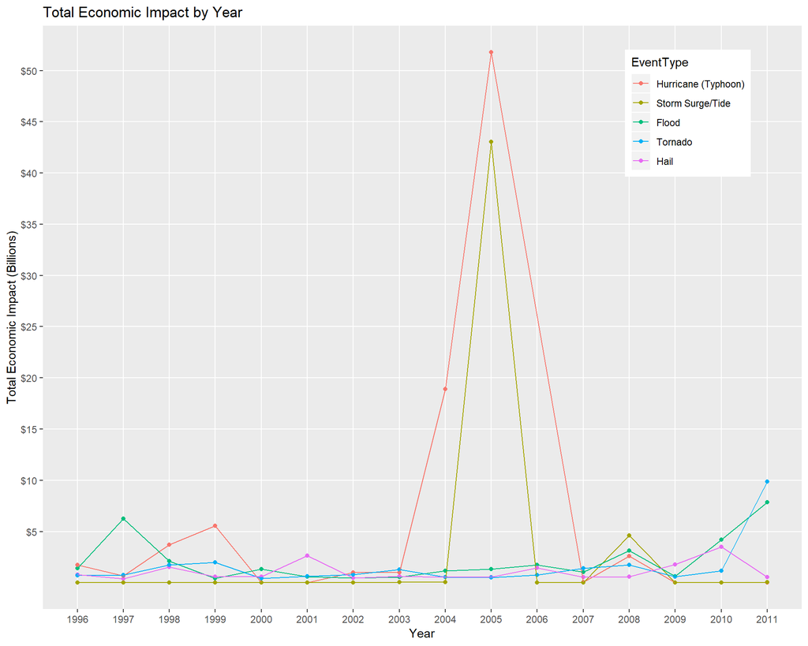

```r
damage_by_type_and_year <-  aggregate(
  cbind(CropDamage,PropDamage,TotalDamage)~EventType+year(BeginDate),
  sd,
  FUN=sum
)
names(damage_by_type_and_year) <- c('EventType', 'Year', 'CropDamage', 'PropDamage', 'TotalDamage')
sd_dmg_yearly <- damage_by_type_and_year[damage_by_type_and_year$EventType %in% top_damage$EventType,]
sd_dmg_yearly$EventType <- with(sd_dmg_yearly, reorder(EventType, -TotalDamage))
ggplot(sd_dmg_yearly, aes(Year, TotalDamage / 10^9, colour = EventType)) +
  geom_point() + geom_line() +
  scale_x_continuous(breaks = unique(damage_by_type_and_year$Year)) +
  scale_y_continuous(
    'Total Economic Impact (Billions)',
    labels = scales::dollar,
    breaks = seq(5,50, by=5)
  ) +
  ggtitle('Total Economic Impact by Year') +
  theme(
    legend.position = c(0.85, 0.85),
    panel.grid.minor = element_blank()
  )
```

Similarly, as with the top five events for population health impact, the top five event list might look different if it were not for identified outliers. Additional analysis would be needed, but hurricane event’s number one position could be in jeopardy without 2005 and storm surge might not have even made the list at all without it.

## Appendices

#### Top Individual Events By Total Damage

```r
top_events_by_total_damage <- subset(storm_data, BeginDate  >= '1996-01-01')
top_events_by_total_damage <-top_events_by_total_damage [
  order(-top_events_by_total_damage$TotalDamage, top_events_by_total_damage$EVTYPE),
  c('REFNUM', 'STATE', 'BeginDate', 'EVTYPE', 'CROPDMG', 'CROPDMGEXP', 'PROPDMG', 'PROPDMGEXP', 'TotalDamage')
]
kable(
  head(
    top_events_by_total_damage,
    n =5
    ),
  row.names = FALSE,
  caption = 'Top Five Individual Events by Total Economic Damage (prior to data correction)'
)
```

Top Five Individual Events by Total Economic Damage (prior to data correction)

| REFNUM | STATE | BeginDate | EVTYPE | CROPDMG | CROPDMGEXP | PROPDMG | PROPDMGEXP | TotalDamage |
| --- | --- | --- | --- | --- | --- | --- | --- | --- |
| 605943 | CA | 2006-01-01 | FLOOD | 32.5 | M | 115.00 | B | 115032500000 |
| 577616 | LA | 2005-08-29 | STORM SURGE | 0.0 |  | 31.30 | B | 31300000000 |
| 577615 | LA | 2005-08-28 | HURRICANE/TYPHOON | 0.0 |  | 16.93 | B | 16930000000 |
| 581535 | MS | 2005-08-29 | STORM SURGE | 0.0 |  | 11.26 | B | 11260000000 |
| 569288 | FL | 2005-10-24 | HURRICANE/TYPHOON | 0.0 |  | 10.00 | B | 10000000000 |

- REFNUM 605943: NOAA link 1/1/2006, CA, Napa County, Flood, This was determined to be an erroniously entered PROMDMGEXP value.
- REFNUM 577616: NOAA link 8/29/2005, LA, Storm Surge, This entry appears to be consistent with NOAA data and correlates with some significant storm surge activity from Katrina.
- REFNUM 577615: 8/28/2005, LA, Hurricane, Also Hurricane Katrina related, this data was also determined to be consistent with the NOAA database.
- REFNUM 581535: NOAA link 8/29/2005, MS, Storm Surge, Another Katrina related event found to be consistent with NOAA data.
- REFNUM 569288: NOAA link 10/24/2005, FL, Palm Beach, Hurricane, This event due to Hurricane Wilma and was found to be consistent with information in the NOAA database.

#### Top Individual Events By Population Health Impact

The same review of the top 5 individual events for total population health impact was also done and all were found to be in line with the current NOAA data.

```r
top_events_by_health_impact <- subset(storm_data, BeginDate  >= '1996-01-01')
top_events_by_health_impact <-top_events_by_health_impact [
  order(-top_events_by_health_impact$PopulationHealthImpact, top_events_by_health_impact$EVTYPE),
 c('REFNUM', 'STATE', 'BeginDate', 'EVTYPE', 'INJURIES', 'FATALITIES', 'PopulationHealthImpact')
]
kable(
  head(
    top_events_by_health_impact,
    n =5
    ),
  row.names = FALSE,
  caption = 'Top Five Individual Events by Population Health Impact'
)
```

Top Five Individual Events by Population Health Impact

| REFNUM | STATE | BeginDate | EVTYPE | INJURIES | FATALITIES | PopulationHealthImpact |
| --- | --- | --- | --- | --- | --- | --- |
| 862563 | MO | 2011-05-22 | TORNADO | 1150 | 158 | 1308 |
| 860355 | AL | 2011-04-27 | TORNADO | 800 | 44 | 844 |
| 344098 | TX | 1998-10-17 | FLOOD | 800 | 2 | 802 |
| 529299 | FL | 2004-08-13 | HURRICANE/TYPHOON | 780 | 7 | 787 |
| 344117 | TX | 1998-10-17 | FLOOD | 750 | 0 | 750 |

- REFNUM 862563: NOAA link 5/22/2011, MO, Jasper, Tornado
- REFNUM 860355: NOAA link 4/27/2011, AL, Tuscaloosa, Tornado
- REFNUM 344098: NOAA link 10/17/1998, TX, Comal, Flood
- REFNUM 529299: NOAA link 8/13/2004, FL, Hurricane
- REFNUM 344117: NOAA link 10/17/1998, TX, Flood